# Root

Vijay

24 February 2018

Data Quality Checks:

Dealing with missing values:

The first step before proceeding to any sort of analysis is cleaning data properly.

Loading data

```r
setwd("C:/Users/katta/Desktop/data_analyst_work_sample")
dat = readRDS('data/sample_trip.rds')
```

Presence of missing values will be problematic for the analysis. Let us deal with them if they are any.

```r
colnas = apply(dat, 2, function(x) sum(is.na(x))) # checking for na's columnwise
colnas
```

```
##  accuracy   heading  latitude longitude     speed timestamp
##         0         0         0         0         1         0
```

```r
i = which(is.na(dat$speed)) # checking for a particular row of na
i
```

```
## [1] 899
```

```r
dat$speed[899] # conforming the location
```

```
## [1] NA
```

```r
dat$speed[899]=dat$speed[898]+dat$speed[900]
colnas = apply(dat, 2, function(x) sum(is.na(x))) # checking the data
colnas
```

```
##  accuracy   heading  latitude longitude     speed timestamp
##         0         0         0         0         0         0
```

Note that completely removing missing value observations may not be a good option here as it complicates further calculations on accelaration and moving average. Now, our data is free of missing values.

Checking for outliers:

Errors might creep into data because of many external factors. One way to check for them is to check for outliers. Although we cannot be sure of all outliers being errors, by removing them we can increase the accuracy of the analysis.

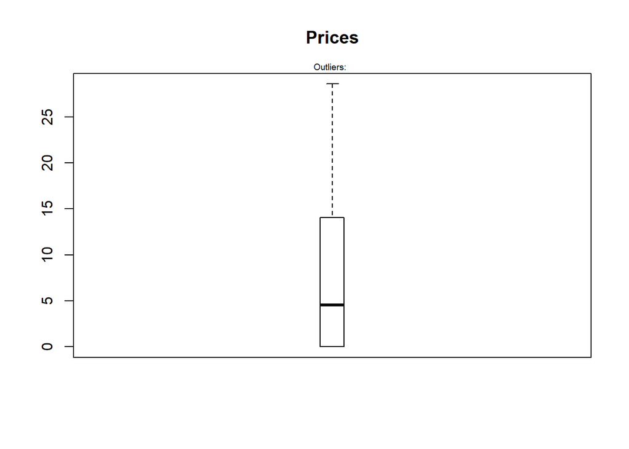

```r
outlier_values1 <- boxplot.stats(dat$speed)$out  # outlier values.
boxplot(dat$speed, main="Prices", boxwex=0.1)
mtext(paste("Outliers: ", paste(outlier_values1, collapse=", ")), cex=0.6)
```

```r
length(outlier_values1) # number of outliers
```

```
## [1] 0
```

There are no outliers in the data.

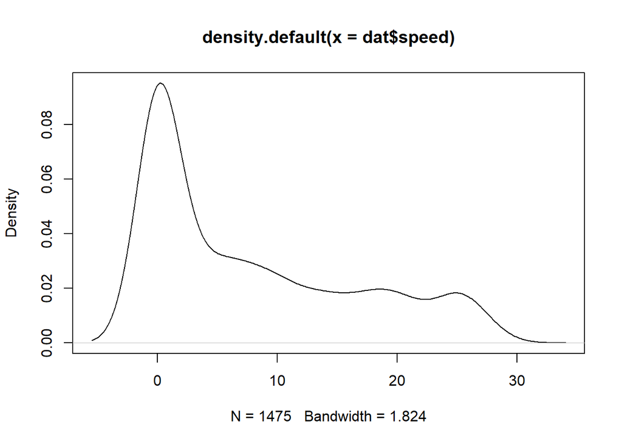

```r
plot(density(dat$speed))
```

```r
summary(as.factor(dat$timestamp))
```

```
## 1516232213 1516231809 1516231810 1516231811 1516231812 1516231813
##          2          1          1          1          1          1
## 1516231814 1516231815 1516231816 1516231817 1516231818 1516231819
##          1          1          1          1          1          1
## 1516231820 1516231821 1516231822 1516231823 1516231824 1516231825
##          1          1          1          1          1          1
## 1516231826 1516231827 1516231828 1516231829 1516231830 1516231831
##          1          1          1          1          1          1
## 1516231832 1516231833 1516231834 1516231835 1516231836 1516231837
##          1          1          1          1          1          1
## 1516231838 1516231839 1516231840 1516231841 1516231842 1516231843
##          1          1          1          1          1          1
## 1516231844 1516231845 1516231846 1516231847 1516231848 1516231849
##          1          1          1          1          1          1
## 1516231850 1516231851 1516231852 1516231853 1516231854 1516231855
```

[output cut: 19 more lines]

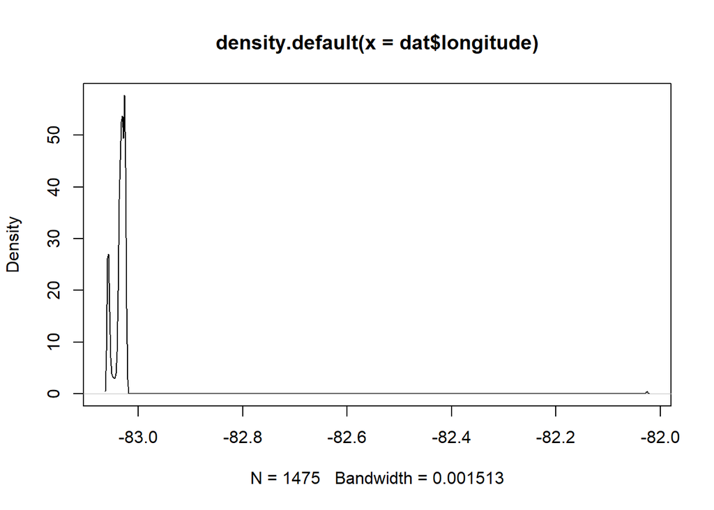

```r
plot(density(dat$longitude))
```

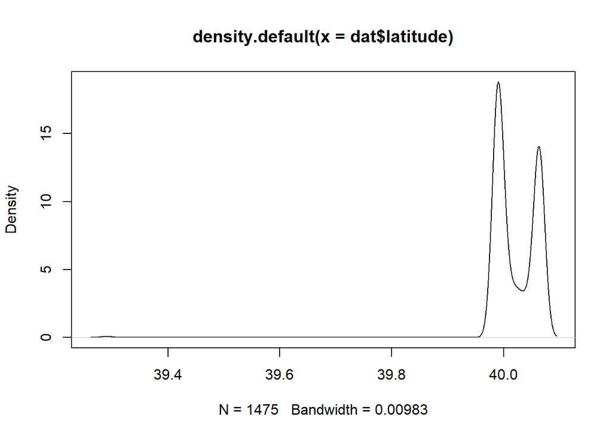

```r
plot(density(dat$latitude))
```

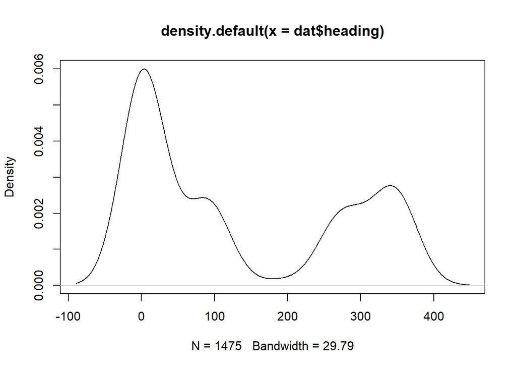

```r
plot(density(dat$heading))
```

```r
dat$latitude[dat$latitude<39.4] # checking for values
```

```
## [1] 39.29031 39.29039 39.29046
```

```r
which(dat$latitude<39.4) # finding indexes
```

```
## [1] 500 501 502
```

```r
dat$latitude[495:505] # observing the pattern
```

```
##  [1] 39.99000 39.99007 39.99013 39.99018 39.99024 39.29031 39.29039
##  [8] 39.29046 39.99052 39.99058 39.99064
```

```r
dat$longitude[dat$longitude>(-82.2)] # checking for values
```

```
## [1] -82.02580 -82.02582 -82.02583
```

```r
which(dat$longitude>(-82.2)) # finding indexes
```

```
## [1] 500 501 502
```

```r
dat$longitude[495:505] # observing the pattern
```

```
##  [1] -83.02579 -83.02580 -83.02580 -83.02580 -83.02580 -82.02580 -82.02582
##  [8] -82.02583 -83.02584 -83.02585 -83.02585
```

From the pattern, we could see that the three values are meant to be 39.9xx instead of 39.2XX in case of latitudes. In case of longitudes, it should be 83.xx instead of 82.xx. Let us correct the data manually.

```r
dat$latitude[500:502]=c(39.99031,39.99039,39.99046)
dat$longitude[500:502] = c(-83.02580,-83.02582,-83.02583)
```

From the summary on time stamp, we could see that there are two values of 151623213. Let’s correct it before further analysis.

```r
dat$timestamp[400] = 1516232211
```

Corrected heading values:

Heading values where the velocity is zero was always zero. But in reality, we know that car has stopped. So in those cases, we can use previous heading value where the heading is non-zero in place of zero.

```r
i = which(dat$heading==0)
for (x in i ) {
  dat$heading[x] = dat$heading[x-1]
}
```

Problem 1: Analyze the enclosed trip data (sample trip.csv) and provide the following summary details (showing work via commented code): . Total trip duration [s] . Total trip distance, computed in two ways [mi] . Turns larger than 60 degrees (count, as well as their location and time) Note, be on the lookout for all sorts of bad data, including missing data, suspicious values, strange formatting, etc.

```r
Total_trip_duration = length(dat$timestamp)-1
```

Total trip duration is 1474 seconds

Calculating distance:

One way of calculating distance is to find average velocity during the trip and multiplying by trip duration. Another way is to find the distances using geospatial coordinates.

```r
library(geosphere)
dat[2:1475,7]=dat[1:1474,3]
dat[2:1475,8]=dat[1:1474,4]
dat[2:1475,9]=apply(dat[2:1475,], 1, function(x) distm(c(x[4], x[3]), c(x[8], x[7]), fun = distHaversine))
dis = sum(dat[2:1475,9]) # 13210.597 meters

dist = (sum(dat[,5])/1475)*1474 # 11471.407 meters
```

Calculating turns:

```r
dat$turn[2:length(dat$accuracy)]= diff(dat$heading, lag = 1)
turns = dat[(abs(dat$turn)>60 & abs(dat$turn)<300 ),c(3,4,6,10)]
turns = turns[-1,] # removing missing value row
```

Problem 2: Run the enclosed R script (mock function.R) and troubleshoot the code to eliminate the errors and/or bad values. If possible, clean the data so that the code gives reasonable results. In addition, comment on the two subfunctions, whether or not they are effective in completing their specified purpose, and how they could be improved.

Mock function:

```r
library(dplyr)
sample_trip = readRDS('data/sample_trip.rds')



sample_trip = dat # lets use clean data

get_acceleration = function(time_vect, speed_vect, lag = 1) {
  dt = diff(time_vect, lag = lag)
  dv = diff(speed_vect, lag = lag)
  accel = dv/dt
  return(accel)
}

fix_speed = function(time_vect, speed_vect,
                     accuracy_vect, accuracy_thresh = 25) {
  bad_accuracy = accuracy_vect > accuracy_thresh
  start_bad = min(which(bad_accuracy))
  end_bad = max(which(bad_accuracy))
  new_speed = approx(x = time_vect[c(start_bad-1, end_bad+1)],
                     y = speed_vect[c(start_bad-1, end_bad+1)],
                     xout = time_vect[bad_accuracy])$y
  speed_vect[bad_accuracy] = new_speed
  return(speed_vect)
}

sample_trip = sample_trip %>%
  mutate(smooth_speed = fix_speed(timestamp, speed, accuracy))

summary = sample_trip %>%
  summarize(max_speed = max(speed),
            max_accel_lag1 = get_acceleration(timestamp, smooth_speed, lag = 1) %>% max,
            max_accel_lag2 = get_acceleration(timestamp, smooth_speed, lag = 2) %>% max,
            max_accel_lag3 = get_acceleration(timestamp, smooth_speed, lag = 3) %>% max)

print(summary)
```

```
##   max_speed max_accel_lag1 max_accel_lag2 max_accel_lag3
## 1     28.58       26.86182       13.43015       8.952922
```

First function “get_acceleration”" calculates the acceleration at a point based on velocity difference over past few seconds. The number of seconds can be given by argument “lag”.

The second function “fix_speed” tries to approximate the velocities with bad accuracy by fitting a line. It takes the observations starting from first inaccurate observation to the last such observation including one accurate observation on either side. The problem arises when there is a chunk of inaccurate observations all at one place. In that case, the function will interpolate the line based on bad observations leading to inaccurate results.

One improvement is to consider only accurate values for interpolation and approximating the inaccurate values based on the line. Another thing is to approximate the velocity based on geospatial coordinates ( assuming given accuracy in the data is meant to be only for speed calculation).